# 1. IMPORTING LIBRARIES

# 3.5 CALUCLATING CORRELATION MATRIX

```python
data.corr()
```

|  | ID | Age | Experience | Income | ZIP Code | Family | CCAvg | Education | Mortgage | Personal Loan | Securities Account | CD Account | Online | CreditCard |
| --- | --- | --- | --- | --- | --- | --- | --- | --- | --- | --- | --- | --- | --- | --- |
| ID | 1.000000 | -0.008473 | -0.009339 | -0.017695 | 0.013432 | -0.016797 | -0.024675 | 0.021463 | -0.013920 | -0.024801 | -0.016972 | -0.006909 | -0.002528 | 0.017028 |
| Age | -0.008473 | 1.000000 | 0.977182 | -0.055269 | -0.029216 | -0.046418 | -0.052012 | 0.041334 | -0.012539 | -0.007726 | -0.000436 | 0.008043 | 0.013702 | 0.007681 |
| Experience | -0.009339 | 0.977182 | 1.000000 | -0.049046 | -0.028492 | -0.045528 | -0.048718 | 0.018074 | -0.013365 | -0.014013 | -0.000465 | 0.005526 | 0.013459 | 0.008834 |
| Income | -0.017695 | -0.055269 | -0.049046 | 1.000000 | -0.016410 | -0.157501 | 0.645984 | -0.187524 | 0.206806 | 0.502462 | -0.002616 | 0.169738 | 0.014206 | -0.002385 |
| ZIP Code | 0.013432 | -0.029216 | -0.028492 | -0.016410 | 1.000000 | 0.011778 | -0.004061 | -0.017377 | 0.007383 | 0.000107 | 0.004704 | 0.019972 | 0.016990 | 0.007691 |
| Family | -0.016797 | -0.046418 | -0.045528 | -0.157501 | 0.011778 | 1.000000 | -0.109275 | 0.064929 | -0.020445 | 0.061367 | 0.019994 | 0.014110 | 0.010354 | 0.011588 |
| CCAvg | -0.024675 | -0.052012 | -0.048718 | 0.645984 | -0.004061 | -0.109275 | 1.000000 | -0.136124 | 0.109905 | 0.366889 | 0.015086 | 0.136534 | -0.003611 | -0.006689 |
| Education | 0.021463 | 0.041334 | 0.018074 | -0.187524 | -0.017377 | 0.064929 | -0.136124 | 1.000000 | -0.033327 | 0.136722 | -0.010812 | 0.013934 | -0.015004 | -0.011014 |
| Mortgage | -0.013920 | -0.012539 | -0.013365 | 0.206806 | 0.007383 | -0.020445 | 0.109905 | -0.033327 | 1.000000 | 0.142095 | -0.005411 | 0.089311 | -0.005995 | -0.007231 |
| Personal Loan | -0.024801 | -0.007726 | -0.014013 | 0.502462 | 0.000107 | 0.061367 | 0.366889 | 0.136722 | 0.142095 | 1.000000 | 0.021954 | 0.316355 | 0.006278 | 0.002802 |
| Securities Account | -0.016972 | -0.000436 | -0.000465 | -0.002616 | 0.004704 | 0.019994 | 0.015086 | -0.010812 | -0.005411 | 0.021954 | 1.000000 | 0.317034 | 0.012627 | -0.015028 |
| CD Account | -0.006909 | 0.008043 | 0.005526 | 0.169738 | 0.019972 | 0.014110 | 0.136534 | 0.013934 | 0.089311 | 0.316355 | 0.317034 | 1.000000 | 0.175880 | 0.278644 |
| Online | -0.002528 | 0.013702 | 0.013459 | 0.014206 | 0.016990 | 0.010354 | -0.003611 | -0.015004 | -0.005995 | 0.006278 | 0.012627 | 0.175880 | 1.000000 | 0.004210 |
| CreditCard | 0.017028 | 0.007681 | 0.008834 | -0.002385 | 0.007691 | 0.011588 | -0.006689 | -0.011014 | -0.007231 | 0.002802 | -0.015028 | 0.278644 | 0.004210 | 1.000000 |

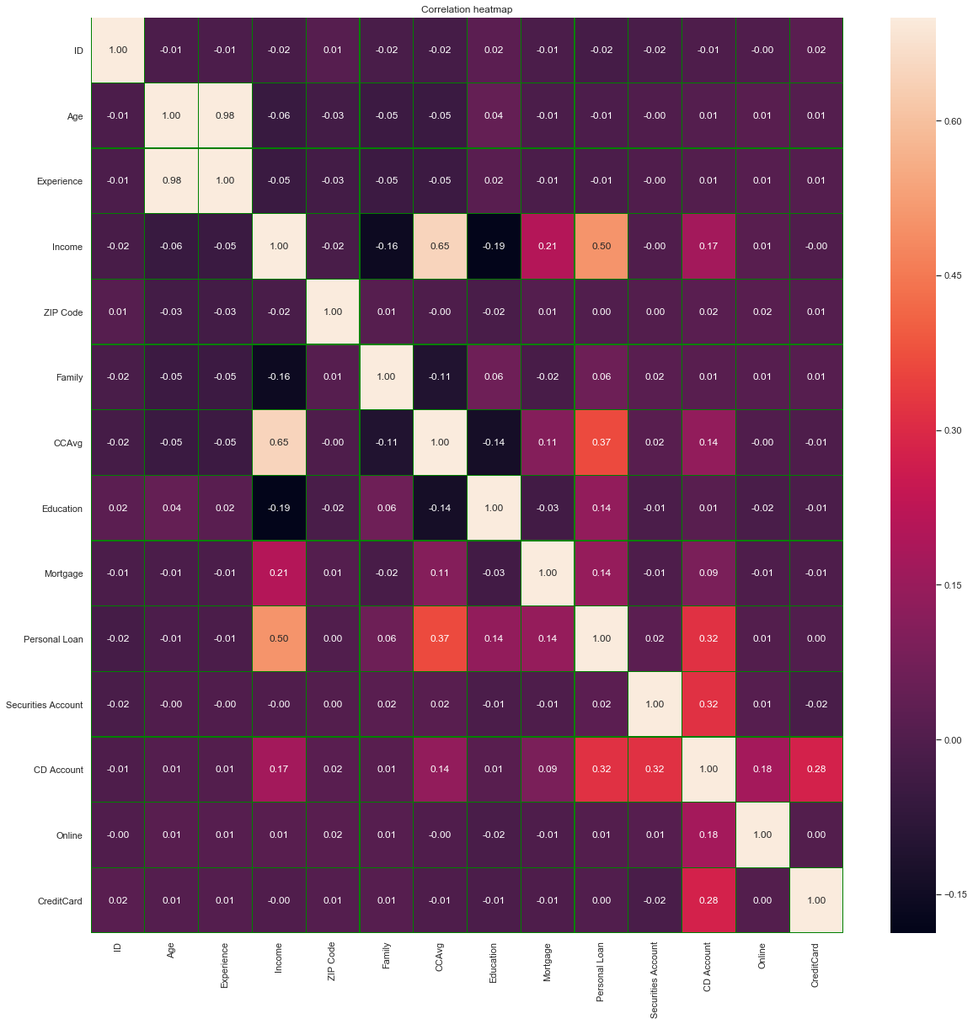

```python
from matplotlib import pyplot as plt
plt.figure(figsize=(20, 20))
ax = sns.heatmap(data.corr(), vmax=.7, square=False, fmt='.2f', annot=True, linecolor='green', linewidths=0.2)
plt.title('Correlation heatmap')
plt.show()
```

Observation:

- Age and Experience are highyly corelated
- Income and CCavg are highly corelated
- No two independent attributes in this given dataset are highly corelated negatively

# 4. GETTING THE TARGET COLUMN

```python
#Normalizing the data
cols_to_norm = ['Age','Experience','Income','CCAvg','Mortgage']
data[cols_to_norm]=data[cols_to_norm].apply(lambda x: (x - x.min()) / (x.max() - x.min()))
```

```python
#id and zipcode are also removed for predictor feature columns as they are very low use
X = data.drop(['ID','ZIP Code','Personal Loan'],axis=1)     # Predictor feature columns
Y = data['Personal Loan']   # Predicted class
```

# 4.1 Comments:

There is an imbalance in the dataset. As the count of those who took personal loan is less when compared with ones who did not

```python
data['Personal Loan'].value_counts()
```

```
0    4520
1     480
Name: Personal Loan, dtype: int64
```

# 5. SPLITTING THE DATA INTO TRAIN AND TEST

```python
from sklearn.model_selection import train_test_split
x_train, x_test, y_train, y_test = train_test_split(X, Y, test_size=0.3, random_state=42)
# 1 is just any random seed number
x_train.head()
```

|  | Age | Experience | Income | Family | CCAvg | Education | Mortgage | Securities Account | CD Account | Online | CreditCard |
| --- | --- | --- | --- | --- | --- | --- | --- | --- | --- | --- | --- |
| 1840 | 0.727273 | 0.608696 | 0.069444 | 4 | 0.04 | 3 | 0.138583 | 0 | 0 | 0 | 0 |
| 2115 | 0.772727 | 0.739130 | 0.101852 | 3 | 0.14 | 1 | 0.000000 | 0 | 0 | 0 | 0 |
| 4437 | 0.909091 | 0.891304 | 0.254630 | 2 | 0.15 | 1 | 0.000000 | 0 | 0 | 1 | 0 |
| 1146 | 0.181818 | 0.217391 | 0.291667 | 1 | 0.01 | 1 | 0.122835 | 1 | 0 | 0 | 0 |
| 2486 | 0.863636 | 0.847826 | 0.564815 | 1 | 0.13 | 1 | 0.404724 | 0 | 0 | 0 | 0 |

# 6. Machine Learning Models Before Upsampling

# 6.1 KNN

```python
leaf_size = [30,40]
n_neighbors = [1,3,5,7,9,15,21,31,41,51]
#Power parameter for the Minkowski metric ----p
p=[1,2]
#Convert to dictionary
hyperparameters = dict(leaf_size=leaf_size, n_neighbors=n_neighbors, p=p)
#Create new KNN object
knn = KNeighborsClassifier()
#Use GridSearch
clf = GridSearchCV(knn, hyperparameters, cv=3)
#Fit the model
model = clf.fit(x_train,y_train)
print('Best leaf_size:', model.best_estimator_.get_params()['leaf_size'])
print('Best p:', model.best_estimator_.get_params()['p'])
print('Best n_neighbors:', model.best_estimator_.get_params()['n_neighbors'])
```

```
Best leaf_size: 30
Best p: 1
Best n_neighbors: 1
```

# Fitting with the best Parameters

```
Accuracy:  0.952

Confusion Matrix
[[1332   11]
 [  61   96]]
```

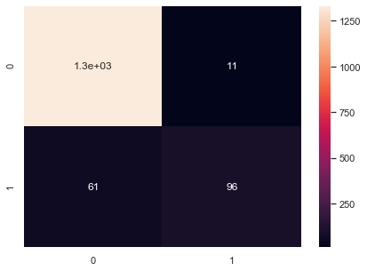

```
classification report for test data:
              precision    recall  f1-score   support

     class 0       0.96      0.99      0.97      1343
     class 1       0.90      0.61      0.73       157

    accuracy                           0.95      1500
   macro avg       0.93      0.80      0.85      1500
weighted avg       0.95      0.95      0.95      1500
```

```python
k=model.best_estimator_.get_params()['n_neighbors']
l=model.best_estimator_.get_params()['leaf_size']
P=model.best_estimator_.get_params()['p']
knn=KNeighborsClassifier(n_neighbors=P,leaf_size=l,p=P)
knn.fit(x_train,y_train)
predicted_labels = knn.predict(x_test)
knn.score(x_test, y_test)
print("Accuracy: ",knn.score(x_test, y_test))
print(" "*100)
print("Confusion Matrix")
cm=metrics.confusion_matrix(y_test, predicted_labels)
print(cm)
df_cm = pd.DataFrame(cm)
plt.figure(figsize = (7,5))
sns.heatmap(df_cm, annot=True)
plt.show()
target_names = ['class 0', 'class 1']
print(" "*100)
print("classification report for test data:")
print(classification_report(y_test, predicted_labels, target_names=target_names))
```

The confusion matrix

True Negatives (TN): we correctly predicted that they did not take Personal Loan 1332

False Positives (FP): we incorrectly predicted that they took Personal Loan (a "Type I error") 11 Falsely predict positive Type I error

False Negatives (FN): we incorrectly predicted that they did not take Personal Loan (a "Type II error") 61 Falsely predict negative Type II error

True Positives (TP): we correctly predicted that they do took Personal Loan 96

#### A small k captures too much training noise and hence does not do well in test data. A very large k does so much smoothening that it does not manage to capture information in the training data sufficiently - and hence does not do well in test data.

# 6.2 Logistic Regression

```python
C=[0.01, 0.1, 1, 5,10, 20, 30]
penalty=['l2','l1']
hyperparameters=dict(C=C, penalty=penalty)
lr=LogisticRegression()
clf = GridSearchCV(lr, hyperparameters, cv=3, verbose=0)
best_model=clf.fit(x_train,y_train)
# View best hyperparameters
print('Best Penalty:', best_model.best_estimator_.get_params()['penalty'])
print('Best C:', best_model.best_estimator_.get_params()['C'])
best_penalty=best_model.best_estimator_.get_params()['penalty']
best_c=best_model.best_estimator_.get_params()['C']
```

```
Best Penalty: l2
Best C: 20
```

# Fitting with the best Parameters

```
Accuracy:  0.9513333333333334

Confusion Matrix
[[1324   19]
 [  54  103]]
```

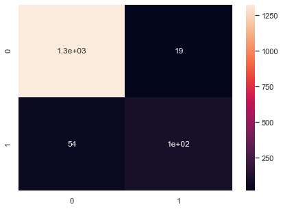

```
classification report for test data:
              precision    recall  f1-score   support

     class 0       0.96      0.99      0.97      1343
     class 1       0.84      0.66      0.74       157

    accuracy                           0.95      1500
   macro avg       0.90      0.82      0.86      1500
weighted avg       0.95      0.95      0.95      1500
```

```python
lr=LogisticRegression(C=best_c,penalty=best_penalty)
lr.fit(x_train,y_train)

predicted_labels = lr.predict(x_test)
lr.score(x_test, y_test)
print("Accuracy: ",lr.score(x_test, y_test))
print(" "*100)
print("Confusion Matrix")
cm=metrics.confusion_matrix(y_test, predicted_labels)
print(cm)
df_cm = pd.DataFrame(cm)
plt.figure(figsize = (7,5))
sns.heatmap(df_cm, annot=True)
plt.show()
target_names = ['class 0', 'class 1']
print(" "*100)
print("classification report for test data:")
print(classification_report(y_test, predicted_labels, target_names=target_names))
```

The confusion matrix

True Negatives (TN): we correctly predicted that they did not take Personal Loan 1324

False Positives (FP): we incorrectly predicted that they took Personal Loan (a "Type I error") 19 Falsely predict positive Type I error

False Negatives (FN): we incorrectly predicted that they did not take Personal Loan (a "Type II error") 54 Falsely predict negative Type II error

True Positives (TP): we correctly predicted that they do took Personal Loan 103

# 6.3 Naive Bayes

```
Accuracy:  0.8926666666666667

Number of mislabeled points out of a total 1500 points : 161

Confusion Matrix
[[1245   98]
 [  63   94]]
```

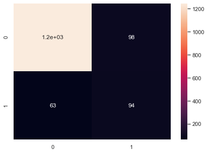

```
classification report for test data:
              precision    recall  f1-score   support

     class 0       0.95      0.93      0.94      1343
     class 1       0.49      0.60      0.54       157

    accuracy                           0.89      1500
   macro avg       0.72      0.76      0.74      1500
weighted avg       0.90      0.89      0.90      1500
```

```python
gnb = GaussianNB()
gnb.fit(x_train,y_train)
predicted_labels=gnb.predict(x_test)
print("Accuracy: ",gnb.score(x_test, y_test))
print(" "*100)
print("Number of mislabeled points out of a total %d points : %d"
       % (x_test.shape[0], (y_test != predicted_labels).sum()))
print(" "*100)
print("Confusion Matrix")
cm=metrics.confusion_matrix(y_test, predicted_labels)
print(cm)
df_cm = pd.DataFrame(cm)
plt.figure(figsize = (7,5))
sns.heatmap(df_cm, annot=True)
plt.show()
target_names = ['class 0', 'class 1']
print(" "*100)
print("classification report for test data:")
print(classification_report(y_test, predicted_labels, target_names=target_names))
```

The confusion matrix

True Negatives (TN): we correctly predicted that they did not take Personal Loan 1245

False Positives (FP): we incorrectly predicted that they took Personal Loan (a "Type I error") 98 Falsely predict positive Type I error

False Negatives (FN): we incorrectly predicted that they did not take Personal Loan (a "Type II error") 63 Falsely predict negative Type II error

True Positives (TP): we correctly predicted that they do took Personal Loan 94

# 6.4 Support Vector Machine

```python
from sklearn.svm import SVC
# defining parameter range
param_grid = {'C': [0.01, 0.1, 1, 10],
              'gamma': [1, 0.1, 0.01, 0.001],
              'kernel': ['rbf','linear']}

grid = GridSearchCV(SVC(), param_grid, refit = True, verbose = 3)

# fitting the model for grid search
best_model=grid.fit(x_train, y_train)

# View best hyperparameters
print('Best gamma:', best_model.best_estimator_.get_params()['gamma'])
print('Best C:', best_model.best_estimator_.get_params()['C'])
print('Best kernel:', best_model.best_estimator_.get_params()['kernel'])
best_gamma=best_model.best_estimator_.get_params()['gamma']
best_c=best_model.best_estimator_.get_params()['C']
best_kernel=best_model.best_estimator_.get_params()['kernel']
print("Best Score:", best_model.best_score_)
```

[output not shown]

[output not shown]

[output not shown]

[output cut: 264 more lines]

```
[CV] ....... C=10, gamma=0.001, kernel=rbf, score=0.907, total=   0.1s
[CV] C=10, gamma=0.001, kernel=linear ................................
[CV] .... C=10, gamma=0.001, kernel=linear, score=0.950, total=   0.0s
[CV] C=10, gamma=0.001, kernel=linear ................................
[CV] .... C=10, gamma=0.001, kernel=linear, score=0.960, total=   0.1s
[CV] C=10, gamma=0.001, kernel=linear ................................
[CV] .... C=10, gamma=0.001, kernel=linear, score=0.946, total=   0.0s
[CV] C=10, gamma=0.001, kernel=linear ................................
[CV] .... C=10, gamma=0.001, kernel=linear, score=0.946, total=   0.1s
[CV] C=10, gamma=0.001, kernel=linear ................................
[CV] .... C=10, gamma=0.001, kernel=linear, score=0.957, total=   0.0s
Best gamma: 0.1
Best C: 10
Best kernel: rbf
Best Score: 0.9777142857142858
```

[output not shown]